# 21.10. Предварительная проверка результатов TotalSegmentator на исторической контрастной КТ

## Резюме

Для одной исторической серии КТ сопоставлены два способа выделения полостей сердца на 20 фазах реконструкции. Первый способ использует контуры, заданные по КТ исходной фазы, их перенос по деформации изображения и пороговое выделение ярких вокселей. Второй способ — TotalSegmentator v2. Расчёт охватывает оба желудочка, оба предсердия, а также отдельные кандидатные маски наружной области сердца и ткани стенки.

**Основной результат пересмотра:** прежнее сравнение смешивало геометрическую область камеры и её яркое подмножество, а перенос контуров давал значительные ошибки разделения правых камер. После прямой перерисовки двух фаз и раздельного учёта этих определений расхождение изменений ПЖ уменьшилось с 62,26 до 4,98 мл, ПП — с 65,96 до 7,22 мл. Для ЛЖ прежняя близость оказалась неустойчивой: расхождение выросло с 4,24 до 16,44 мл. Эти числа характеризуют различие способов, а не установленную погрешность TotalSegmentator.

**Итог проверки:** TotalSegmentator сохраняется как рабочий источник автоматической сегментации для дальнейших исследовательских расчётов. В этой серии проверены соответствие входных данных, физических сеток и подсчёт объёмов; на двух подробно просмотренных фазах основные камеры анатомически распознаются, а направление изменения объёма совпадает с прямой обводкой для всех четырёх камер. Вместе с тем точность абсолютных объёмов и амплитуд их изменений относительно независимого референса не установлена.

**Доказательный статус:** это предварительная вычислительная и анатомическая проверка. Она обосновывает сохранение автоматического метода в исследовательской работе и показывает несостоятельность прежнего кандидата как эталона. Тезис о доказанной количественной точности TotalSegmentator по результатам настоящего опыта не подтверждён; его ложность также не установлена.

Расчёт всех 20 фаз завершён. Подробно просмотрены 96 аксиальных срезов двух фаз, исправлены кандидатные области камер и подготовлены редактируемые проекты. Разделы 3–5 сохраняют исходный расчёт для воспроизводимости; **актуальная анатомическая ревизия и её объяснение представлены в разделе 6**, итоговые ограничения — в разделе 7. Полная проверка остальных фаз, миокарда и наружной границы остаётся незавершённой.

## 1. Цель и место исследования

Задача состоит в проверке того, насколько результат TotalSegmentator воспроизводит изменение объёмов камер на протяжении реконструированного сердечного цикла. Для такой проверки нужен второй способ разметки с известными анатомическими границами и достаточной независимостью от проверяемого алгоритма. Совпадение объёмов само по себе не доказывает совпадение границ.

Предыдущий отчёт 21.09 описывает исправление частичных областей желудочков. Здесь рассматривается следующий этап: расширенные области четырёх камер и их динамика. Данные относятся к одной выбранной серии исторической КТ; результаты нельзя переносить на остальные исторические серии или на современные КТ добровольцев без отдельного сравнения.

### 1.1. Проверяемые тезисы и границы доказательства

Общее утверждение «числам TotalSegmentator можно доверять» включает несколько разных вопросов. Здесь они разделены по измеряемой величине и доступным свидетельствам. Такое разделение представляет интерпретацию уже выполненного опыта; оно не является заранее зарегистрированным протоколом с установленным допуском ошибки.

| Проверяемый тезис | Свидетельства настоящего опыта | Вывод |
| --- | --- | --- |
| Из сохранённых масок корректно рассчитывается объём в мл | Проверки исходной КТ, геометрии и единиц, контрольных сумм, бинарности и непересечения; вычислительные тесты разностей | Подсчёт объёма на проверенных входах прошёл техническую проверку |
| Автоматическая разметка отражает крупные камеры и направление их изменения | Просмотр 96 аксиальных срезов фаз 0 и 40%; знаки изменений по прямым контурам и TotalSegmentator совпадают для четырёх камер | Предварительно поддержано только для просмотренных областей и данной пары фаз |
| Прежние большие расхождения правых камер доказывают ошибку TotalSegmentator | Исправление нашего кандидата существенно уменьшает эти расхождения | Прежнее сравнение не позволяет приписать их целиком автоматическому методу |
| Абсолютные объёмы и их изменения достаточно точны для оценки функции сердца | Независимый принятый референс и согласованный численный допуск отсутствуют | Не установлено; количественная валидация остаётся открытой |

Фаза 0% задаёт исходный уровень, а фаза 40% выбрана для подробного разбора после обнаружения выраженного конфликта меток ПЖ и ПП и расхождений динамики предсердий. Такой диагностический выбор помогает установить причины несогласованности, но не образует случайную или репрезентативную выборку фаз для оценки общей точности.

Из совпадения направления изменения не следует совпадение его амплитуды. Аналогично правильный подсчёт вокселей не подтверждает правильность анатомического контура. Поэтому подтверждение первых двух тезисов не переносится автоматически на последний. Уменьшение претензий к алгоритму после исправления сравнения также не задаёт верхнюю границу его ошибки.

## 2. Исходные данные и определения

Использованы 20 объёмов одной контрастной КТ с фазами от 0 до 95% через 5%. Размер массива каждой фазы — 512 × 512 × 103, шаг отсчётов — приблизительно 0,473 × 0,473 × 2,5 мм. Указанная в исходных метаданных толщина среза составляет 5 мм. Шаг 2,5 мм не означает независимое пространственное разрешение 2,5 мм: соседние реконструированные срезы перекрываются. Пересчёт в изотропные воксели не восстановит отсутствующие детали клапанов и тонких стенок.

Обозначения: ЛЖ — левый желудочек, ПЖ — правый желудочек, ЛП — левое предсердие, ПП — правое предсердие. Под объёмом в вычислительных таблицах понимается объём конкретной выделенной области. Для исходного порогового кандидата это яркое подмножество поисковой области; для TotalSegmentator — вся метка камеры; для исправленных прямых контуров — непороговая геометрическая область. Анатомическая эквивалентность этих определений не предполагается. Сумма четырёх масок не включает отдельную метку миокарда и не равна объёму всего сердца; отнесение внутриполостных мышечных структур требует отдельного правила. Наружная область сердца и ткань его стенки рассматриваются отдельно.

Процент фазы задаёт положение в последовательности реконструкции. Фаза 0% выбрана как начало отсчёта изменений, а не как доказанная конечная диастола. Конечная диастола и конечная систола независимо не установлены; ударный объём и фракция выброса здесь не рассчитываются.

| Вход или результат | Происхождение | Доказательный статус |
| --- | --- | --- |
| Изображения и пространственная геометрия КТ | Исходная реконструкция, преобразованная в NIfTI | Измерительные данные и их технические метаданные |
| Контуры исходной фазы | Заданы агентом по разрешённому просмотру обезличенной КТ | Кандидатная анатомическая разметка; экспертно не принята |
| Другие фазы в исходном варианте | Вычислены по деформации КТ и локальному порогу яркости | Результат алгоритма, без независимой ручной обводки каждой фазы |
| Исправленные прямые контуры фаз 0 и 40% | Заданы по КТ без межфазного переноса | Разметка агентом после просмотра TotalSegmentator; независимость отсутствует |
| Маски TotalSegmentator | Версия 2.18.0; задачи общего сердца и камер высокого разрешения | Автоматическая сегментация той же серии |
| Разности объёмов двух способов | Подсчёт вокселей на совпадающих физических сетках | Воспроизводимое расхождение методов; истинная ошибка неизвестна |

## 3. Исходные способы сегментации и введённые допущения

### 3.1. Контуры исходной фазы

Области желудочков были расширены относительно частичных масок отчёта 21.09; дополнительно заданы области предсердий. Опорные контуры интерполированы между срезами. Разделение желудочков и предсердий включает приближённые плоскости клапанных границ. В области правых камер разделяющее правило действует в пересечении их поисковых областей, чтобы не отсечь весь передний выходной тракт одним глобальным сечением.

Границы клапанов, переходы к магистральным сосудам, устья вен и полнота включения ушек предсердий остаются неопределёнными. В частности, верхняя граница кандидатного ПЖ в исходной фазе достигает среза 35, тогда как автоматическая маска продолжается выше. Это различие требует просмотра клапанной области в нескольких плоскостях. Нельзя заранее считать дополнительную область TotalSegmentator сосудом, ошибочно включённым в желудочек.

### 3.2. Перенос на остальные фазы

Изображение каждой целевой фазы совмещено с исходной КТ посредством B-сплайнового поля деформации. При оценке преобразования использованы только изображения КТ; маски TotalSegmentator не участвовали. Вычисление выполнено в ограниченной области сердца на сетке приблизительно 2 × 2 × 2,5 мм, с расстоянием между управляющими узлами 20 мм, тремя уровнями разрешения и лимитом 40 итераций на уровень. Критерий совмещения — взаимная информация.

Преобразование переносит исходные поисковые области на целевую КТ. В каждой области выделяются воксели с интенсивностью не ниже 190 HU; сохраняется крупнейшая компонента с шестисвязным соседством. Дополнительно рассчитаны пороги 170 и 210 HU. Это выбранные вычислительные сценарии, а не литературные границы нормальной плотности крови и не доверительный интервал ошибки. Одинаковый порог не гарантирует одинаковой анатомической полноты при изменении контраста и частичного объёма.

Отдельно сохранён перенос готовых бинарных масок без повторного выделения по интенсивности. Сравнение двух вариантов позволяет оценить, насколько объём определяется деформацией исходной области и насколько — интенсивностью целевой КТ. Ни один вариант не считается эталоном только по внутренней согласованности.

### 3.3. Наружная область и кандидат ткани стенки

Наружный контур задан по исходной КТ и перенесён на остальные фазы. Его границы у основания и сосудов пока не приняты. Из области внутри контура исключены четыре кандидатные полости. Полученный остаток дополнительно ограничен интенсивностью от 0 до 190 HU. В отчёте он назван кандидатом ткани стенки.

Такой остаток может содержать невыделенную кровь, соединительную ткань, участки сосудов и ошибки контура. Поэтому он не эквивалентен морфологически проверенному миокарду. На последующих фазах эта исходная маска переносится как бинарная область; порог ткани заново не применяется. Кривую этого кандидата можно сопоставить с маской миокарда TotalSegmentator только для диагностики различий определений.

### 3.4. Независимость и контроль вычислений

Исходные контуры и правила переноса были зафиксированы до просмотра численного сравнения и автоматических контуров. После этого выявлялись пространственные причины расхождений. Любая следующая коррекция, сделанная с учётом уже увиденных масок TotalSegmentator, должна быть отмечена как разметка без ослепления. Она не становится независимым референсом автоматически.

Перед сравнением проверяются контрольные суммы исходных КТ и масок, соответствие фаз, размеры массивов, аффинные преобразования и единицы миллиметров. Маски должны быть бинарными, непустыми и не пересекаться между камерами одного способа. Эти проверки защищают от подмены серии, ошибки масштаба и двойного подсчёта. Они не устанавливают правильность анатомических границ.

## 4. Расчёт показателей

Объём выделенной области определяется суммой физических объёмов её вокселей:

$$V_c(t)=N_c(t)\,|\det A|/1000,$$

где $N_c(t)$ — число вокселей камеры $c$ на фазе $t$, $A$ — пространственная часть аффинного преобразования в миллиметрах. Деление на 1000 переводит мм³ в мл.

Изменение относительно исходной фазы и расхождение изменений вычисляются как

$$\Delta V_c(t)=V_c(t)-V_c(0),\qquad D_c(t)=\Delta V_c^{TS}(t)-\Delta V_c^{C}(t),$$

где индексы $TS$ и $C$ обозначают TotalSegmentator и кандидатную разметку соответственно. Положительное $D$ означает, что TotalSegmentator даёт большее увеличение или меньшее уменьшение объёма от собственного исходного уровня. Отрицательное значение означает обратное. Постоянное смещение объёма между способами вычитается при расчёте $D$; изменяющееся по фазам смещение сохраняется.

## 5. Исходное сравнение до анатомической ревизии

### 5.1. Абсолютные объёмы

| Камера | Кандидат, фаза 0%, мл | TotalSegmentator, фаза 0%, мл | Различие TS − кандидат, мл |
| --- | --- | --- | --- |
| Левый желудочек | 127.64 | 145.83 | +18.20 |
| Правый желудочек | 120.33 | 196.48 | +76.15 |
| Левое предсердие | 31.85 | 41.98 | +10.13 |
| Правое предсердие | 46.12 | 62.05 | +15.93 |

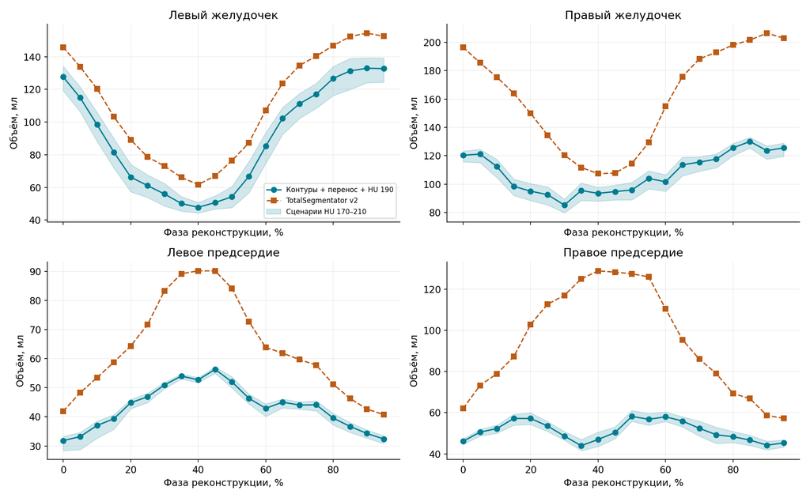

Рисунок 1. Абсолютные объёмы четырёх камер на 20 фазах. Полоса показывает размах результатов трёх пороговых сценариев; она не включает неопределённость клапанных границ и ошибки переноса.

Кривые позволяют разделить два вопроса: совпадают ли сами объёмы и воспроизводится ли их изменение. Различие начальных уровней особенно заметно для ПЖ. Его нельзя устранить выбором другого нуля без проверки того, какие анатомические области дают добавочный объём. Узкая полоса пороговых сценариев также не доказывает точность: одинаково обрезанная поисковая область останется неполной при всех трёх порогах.

### 5.2. Изменения относительно исходной фазы

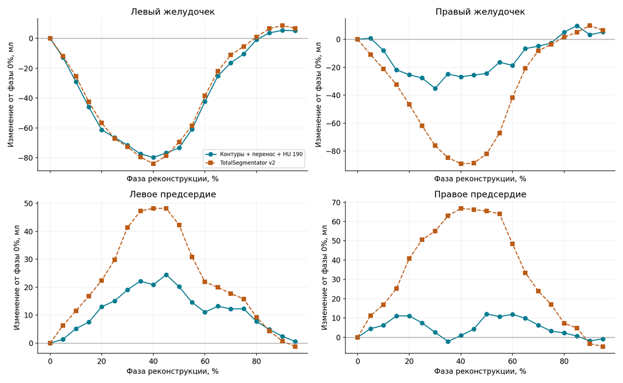

Рисунок 2. Изменения объёмов относительно фазы 0%. Для каждого способа вычтен его собственный исходный объём; график не представляет ударный объём.

| Камера | Фаза | Изменение кандидата, мл | Изменение TS, мл | Различие изменений, мл |
| --- | --- | --- | --- | --- |
| Левый желудочек | 25% | -66.54 | -67.22 | -0.68 |
| Левый желудочек | 50% | -73.31 | -69.42 | +3.89 |
| Левый желудочек | 75% | -10.48 | -5.43 | +5.05 |
| Правый желудочек | 25% | -27.71 | -61.95 | -34.24 |
| Правый желудочек | 50% | -24.46 | -81.93 | -57.46 |
| Правый желудочек | 75% | -2.70 | -3.64 | -0.94 |
| Левое предсердие | 25% | +15.07 | +29.80 | +14.73 |
| Левое предсердие | 50% | +20.17 | +42.21 | +22.05 |
| Левое предсердие | 75% | +12.30 | +15.80 | +3.50 |
| Правое предсердие | 25% | +7.45 | +50.59 | +43.14 |
| Правое предсердие | 50% | +12.08 | +65.43 | +53.34 |
| Правое предсердие | 75% | +3.17 | +16.99 | +13.82 |

На фазе 50% кандидатный объём ЛЖ уменьшается на 73.31 мл, а результат TotalSegmentator — на 69.42 мл. Разность этих изменений составляет +3.89 мл. Таким образом, близость динамики ЛЖ на этой фазе сочетается с различием абсолютных уровней.

Для ПЖ на той же фазе изменения составляют -24.46 и -81.93 мл. Расхождение значительно больше, чем для ЛЖ. Его величина не позволяет считать оба способа взаимозаменяемыми, но не указывает, какой из них анатомически верен. Необходимо проверить разделение ПЖ и ПП и полноту выходного тракта.

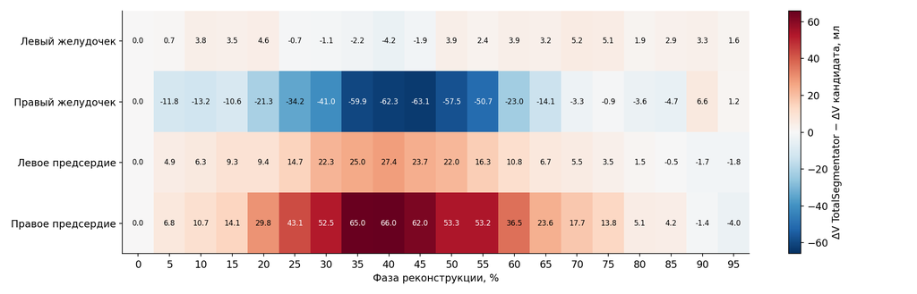

Рисунок 3. Различия изменений объёма: TotalSegmentator минус кандидат. Красный цвет — положительная разность, синий — отрицательная; общий масштаб в миллилитрах одинаков для всех камер.

Карта показывает фазы и камеры, на которых различие методов наиболее выражено. Нулевая первая колонка следует из определения изменения относительно исходной фазы и не является результатом валидации. Для остальных колонок малое значение означает согласованность конкретной разности объёмов; крупные несовпадения границ могут при этом частично компенсироваться.

| Камера | Среднее абсолютное расхождение изменений, мл | Максимум, мл | Фаза максимума |
| --- | --- | --- | --- |
| Левый желудочек | 2.94 | 5.21 | 70% |
| Правый желудочек | 25.43 | 63.15 | 45% |
| Левое предсердие | 11.24 | 27.36 | 40% |
| Правое предсердие | 29.62 | 65.96 | 40% |

В таблице использованы все 19 последующих фаз; исходная фаза исключена, поскольку её разность тождественно равна нулю. Среднее рассчитано по модулям расхождений, чтобы положительные и отрицательные значения не компенсировались. Эти показатели суммируют несогласованность способов в одной серии и не являются оценкой ошибки относительно истинного объёма.

### 5.3. Чувствительность к приближённой границе камер

| Камера | Смещение границы −3 мм, мл | Без смещения, мл | Смещение +3 мм, мл |
| --- | --- | --- | --- |
| Левый желудочек | 123.07 | 127.64 | 131.43 |
| Правый желудочек | 120.33 | 120.33 | 120.33 |
| Левое предсердие | 33.82 | 31.85 | 29.77 |
| Правое предсердие | 46.12 | 46.12 | 46.12 |

На исходной фазе дополнительно рассмотрен сдвиг параметра разделяющей границы на ±3 мм при неизменном пороге 190 HU. Для ЛЖ и ЛП эти сценарии заметно меняют объёмы. Для правых камер значения практически не меняются, поскольку правило действует только в пересечении их заданных поисковых областей. Такой нулевой отклик характеризует ограничение текущей реализации пробы; он не доказывает точность трёхстворчатой границы. Сценарии исходной фазы не являются доверительными интервалами и не охватывают неопределённость динамики клапанного кольца.

### 5.4. Зависимость результата от способа переноса

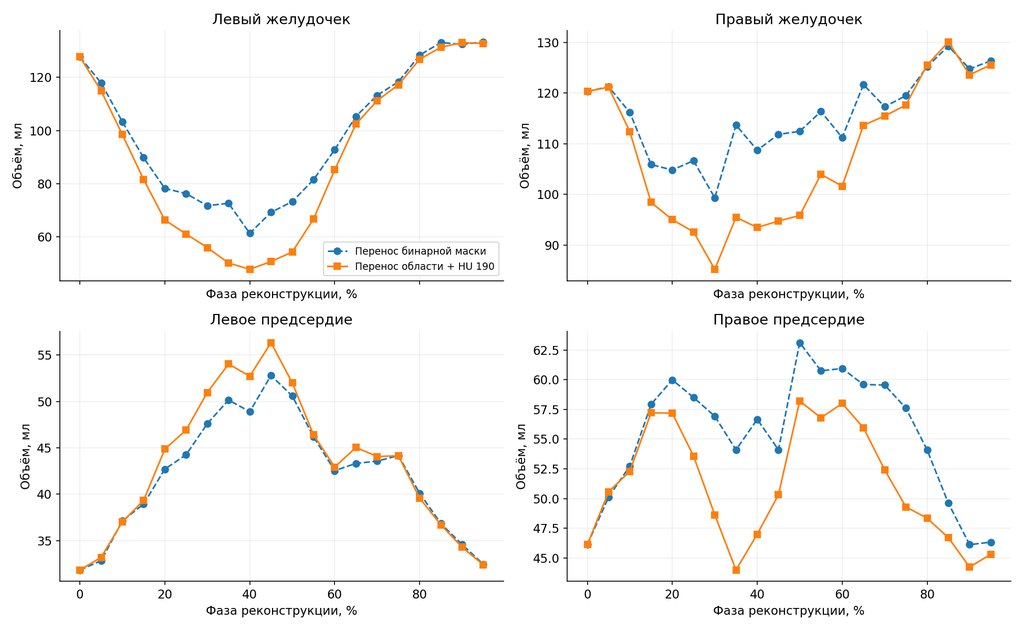

Рисунок 4. Перенос готовой бинарной маски и повторное выделение по интенсивности в перенесённой поисковой области. Оба варианта используют одно поле деформации КТ.

На фазе 50% объём ЛЖ при переносе готовой маски равен 73.27 мл, а после порогового выделения в целевой КТ — 54.32 мл. Различие составляет 18.94 мл. Оно получено на одном изображении и поэтому характеризует зависимость оценки от алгоритма обработки, а не дополнительное физиологическое сокращение.

Пороговое выделение удаляет часть низкоинтенсивных участков, однако не исправляет ошибочное отнесение яркого участка к другой камере. Приближённая клапанная граница и ошибка поля деформации сохраняются. Близость одного из вариантов к TotalSegmentator не является достаточным основанием для его выбора.

### 5.5. Пространственные причины расхождений ПЖ

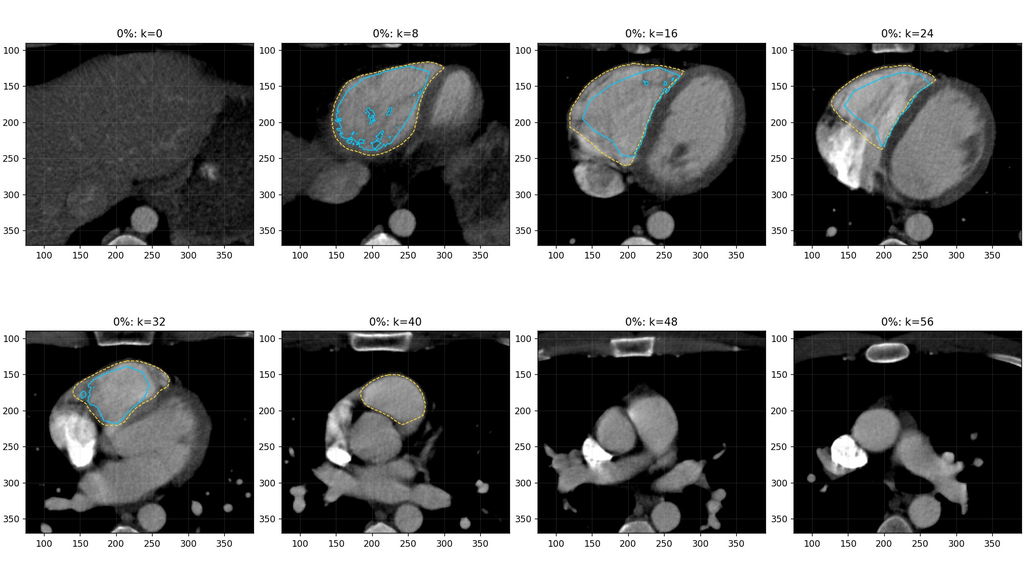

Рисунок 5. ПЖ на исходной фазе: кандидатный контур — голубой сплошной, TotalSegmentator — жёлтый пунктирный. Показаны различия наружного охвата и верхней протяжённости.

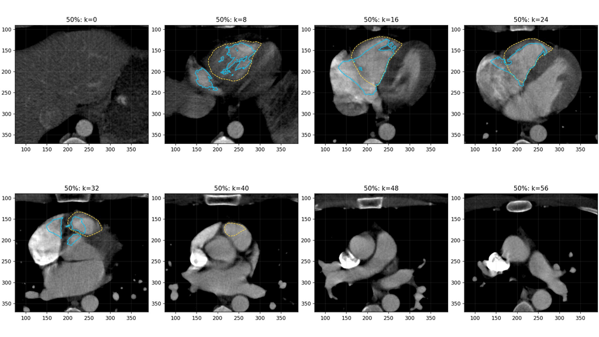

Рисунок 6. ПЖ на фазе 50% при тех же обозначениях. Расхождения включают участки около границы предсердия и выходного тракта; правильность их принадлежности ещё не установлена.

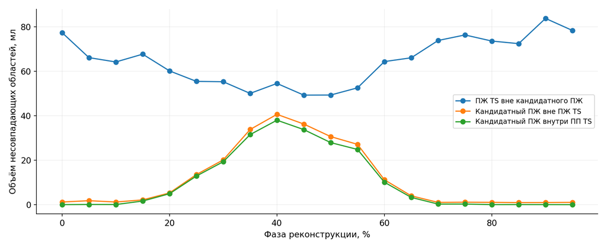

Рисунок 7. Объёмы несовпадающих областей ПЖ. Пересечение кандидатного ПЖ с автоматическим ПП показывает конфликт меток; оно не устанавливает истинную анатомическую принадлежность.

Наибольший конфликт меток ПЖ и ПП обнаружен на фазе 40%: 37.98 мл кандидатного ПЖ попадает в область, которую TotalSegmentator относит к ПП. Эта величина показывает, что расхождение касается не только положения наружного контура, но и разделения камер. Само пересечение не устанавливает, какой способ верен; оно задаёт конкретную область для повторного анатомического просмотра.

В исходной фазе кандидатный ПЖ заканчивается ниже автоматического. На фазе 50% дополнительно видны различия в яркой области около правого предсердия. Эти наблюдения согласуются с недостатками исходной границы и её переноса. Поэтому большое расхождение динамики ПЖ нельзя целиком приписывать TotalSegmentator. Для решения нужны разметка клапанного кольца и прослеживание выходного тракта в согласованных продольных и поперечных плоскостях.

### 5.6. Наружная область и ткань стенки

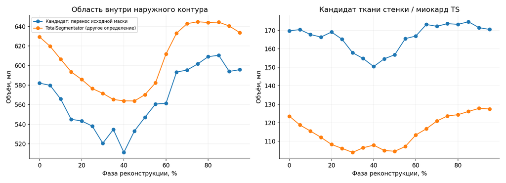

Рисунок 8. Динамика области внутри наружного контура и кандидата ткани стенки в сравнении с соответствующими выходами TotalSegmentator. Определения сопоставляемых областей различаются; разности не являются ошибками миокардиальной сегментации.

Сохранённые маски позволяют просматривать внешнюю геометрию и отделять полости от окружающего остатка. Однако верхнее отсечение наружного контура и низкая тканевая специфичность порогового остатка не позволяют считать задачу сегментации миокарда завершённой. Даже плавная кривая объёма не устраняет эти ограничения. Требуются самостоятельная наружная граница, согласованные сечения сосудов и проверка того, что остаётся после исключения крови.

### 5.7. Техническая проверка деформации

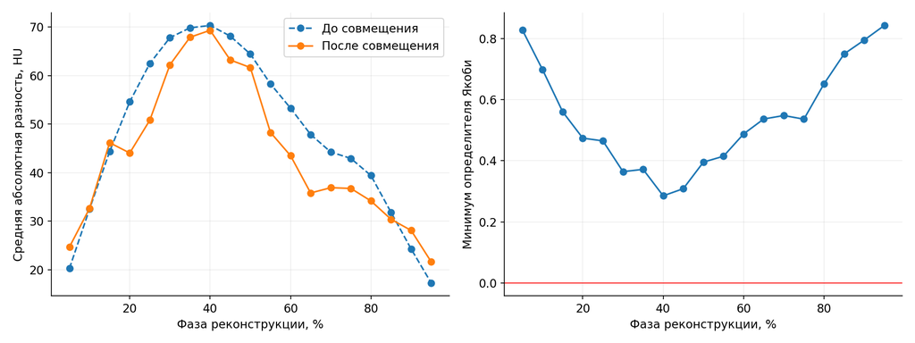

Рисунок 9. Средняя абсолютная разность интенсивностей КТ до и после совмещения и минимум определителя Якоби на расчётной сетке. Фаза 0% исключена, поскольку для неё преобразование тождественно.

Средняя абсолютная разность интенсивностей уменьшилась в 14 из 19 сопоставлений. Минимальное зарегистрированное значение определителя Якоби составляет 0.285; доля неположительных значений на проверенной сетке равна нулю. Это подтверждает отсутствие обнаруженных локальных инверсий на этой сетке. Проверка не исключает ошибок анатомического соответствия и не доказывает положительность во всех точках непрерывного поля.

В 14 сопоставлениях зарегистрировано достижение лимита итераций. Завершение алгоритма поэтому нельзя трактовать как доказанную оптимизационную сходимость. Кроме того, при совмещении оптимизировался критерий взаимной информации, тогда как средняя абсолютная разность служит дополнительным диагностическим показателем. Их изменения не обязаны совпадать.

## 6. Пересмотр результатов после прямого анатомического просмотра

### 6.1. Объём полости и объём вокселей с заданной интенсивностью

При повторной проверке обнаружено принципиальное ограничение исходного сравнения. Автоматическая маска камеры и область, выделенная порогом 190 HU внутри приближённого контура, задают разные измеряемые величины. Первая представляет присвоенную алгоритмом анатомическую область. Вторая содержит только достаточно яркие воксели внутри поисковой области. Их различие зависит от фазы, поэтому вычитание исходного объёма не устраняет его.

Для проверки этого эффекта на всех 20 фазах сохранены неизменными маски TotalSegmentator и отдельно подсчитаны все их воксели и подмножества с интенсивностью не ниже 170, 190 и 210 HU. Тем самым влияние порога исследовано без перемещения границ маски:

$$V_{190}(t)=v\sum_{x\in M(t)}\mathbf{1}\{I(x,t)\geq190\},\qquad V_M(t)=v|M(t)|,$$

где $M(t)$ — автоматическая маска камеры, $I(x,t)$ — интенсивность КТ в HU, а $v$ — физический объём вокселя в мл. Величина

$$B_{190}(t)=[V_{190}(t)-V_{190}(0)]-[V_M(t)-V_M(0)]$$

характеризует изменение результата, вызванное только введением порога. Это диагностический эффект определения объёма; его нельзя интерпретировать как установленную ошибку сегментации крови.

| Камера | Вся маска TS: 0% → 40%, мл | После порога 190 HU: 0% → 40%, мл | Влияние порога на изменение, мл |
| --- | --- | --- | --- |
| ЛЖ | 145.83 → 61.79 | 136.43 → 38.66 | -13.72 |
| ПЖ | 196.48 → 107.39 | 179.39 → 73.52 | -16.78 |
| ЛП | 41.98 → 90.21 | 38.80 → 88.89 | +1.86 |
| ПП | 62.05 → 128.89 | 54.80 → 114.73 | -6.91 |

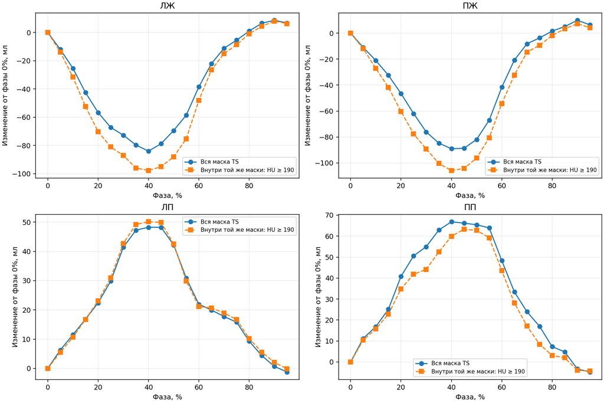

Рисунок 10. Межфазные изменения внутри одних и тех же масок TotalSegmentator: все воксели и только воксели с интенсивностью не ниже 190 HU. Расхождение кривых вызвано пороговой обработкой при неизменных анатомических метках.

Для ЛЖ на фазе 40% порог добавляет 13,72 мл к оценке уменьшения объёма; для ПЖ — 16,78 мл. На всём цикле максимальный модуль этого эффекта достигает 18,67 мл для ЛЖ и 16,78 мл для ПЖ. Следовательно, даже визуально устойчивый порог может существенно искажать оцениваемую амплитуду изменения. Эти числа получены внутри масок TotalSegmentator и не являются поправками, которые можно автоматически вычесть из прежней кривой кандидата.

В маске ЛЖ доля вокселей ниже 170 HU возрастает с 3,0% на исходной фазе до 31,8% на фазе 40%. Низкая интенсивность может быть связана с трабекулами и сосочковыми мышцами, частичным объёмом, неоднородностью контрастирования или ошибками контура. По одному порогу эти причины не разделяются. Поэтому ни все воксели автоматической маски, ни только яркое подмножество нельзя без дополнительной анатомической проверки объявить истинным объёмом крови.

Для оценки функции сердца требуется единое правило включения сосочковых мышц и трабекул во всех фазах и обоих способах разметки. Для электрического моделирования дополнительно требуется различать кровь и ткань миокарда: геометрическая полость с включёнными внутриполостными мышечными структурами не является однородным кровяным компартментом. Совпадение клинической условности обводки и физического определения компартмента пока не установлено.

### 6.2. Исправление прямых контуров двух фаз

Последовательно просмотрены аксиальные срезы 2–49 фаз 0 и 40%: по 48 срезов каждой фазы, сначала с автоматическими контурами, затем с исправленными кандидатными контурами. Это подробный просмотр двух объёмов, а не анатомическая проверка всех 20 фаз. Область выше среза 49 и остальные 18 фаз не размечены вручную заново.

Просмотр подтвердил два недостатка прежнего кандидата. На исходной фазе верхнее ограничение ПЖ срезом 35 исключало часть его переднего выходного отдела. На фазе 40% перенос исходной области относил значительную часть правого предсердия к ПЖ. По пространственному пересечению с автоматической маской ПП объём такого несогласованного участка составлял 37,98 мл. Это локализация расхождения методов, а не автоматически установленный объём ошибочно размеченной ткани.

Для исходной фазы заново заданы контуры ПЖ и ПП; прежние непороговые области ЛЖ и ЛП сохранены. Для фазы 40% заново заданы контуры всех четырёх камер непосредственно по её КТ. Межфазное поле деформации при построении этих новых областей не использовалось. Непороговый объём внутри контура и результаты трёх HU-порогов сохранены раздельно. Неоднозначные пересечения контуров исключены из всех камер и сохранены отдельной маской: 0,138 мл в исходной фазе и 0,366 мл на фазе 40%. Это только объём пересечений, а не полная неопределённость разметки.

Новые контуры создавались после просмотра TotalSegmentator. Поэтому они представляют исправление без ослепления, выполненное агентом, и не являются независимым экспертным референсом. Уровни клапанных отсечений, устья сосудов, ушки предсердий и внутриполостные мышечные структуры остаются источниками неопределённости. Полигональное приближение также ограничивает точность поверхности.

| Камера | Прямые контуры: 0% → 40%, мл | Изменение по прямым контурам, мл | Изменение TS, мл | TS − прямые контуры: различие изменений, мл |
| --- | --- | --- | --- | --- |
| ЛЖ | 148.98 → 48.49 | -100.49 | -84.05 | +16.44 |
| ПЖ | 171.34 → 87.23 | -84.11 | -89.09 | -4.98 |
| ЛП | 41.32 → 75.27 | +33.95 | +48.23 | +14.28 |
| ПП | 49.98 → 109.60 | +59.62 | +66.84 | +7.22 |

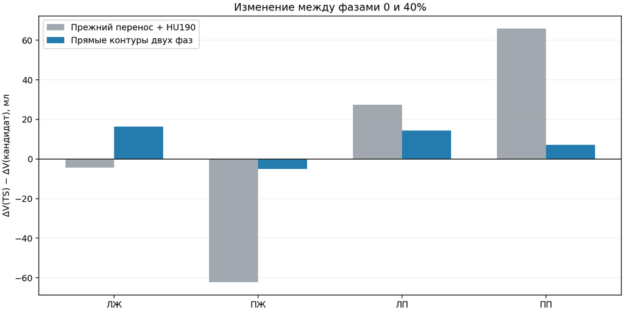

Рисунок 11. Расхождение межфазного изменения TotalSegmentator с прежним и исправленным кандидатами. Отрицательное значение означает более сильное уменьшение или менее сильное увеличение по TotalSegmentator. Сравнение относится только к переходу 0 → 40%.

Для ПЖ модуль расхождения уменьшился с 62,26 до 4,98 мл; для ПП — с 65,96 до 7,22 мл. Таким образом, прежние большие расхождения правых камер существенно зависели от дефектов нашего кандидата. Их нельзя предъявлять как доказанную ошибку TotalSegmentator. Одновременно для ЛЖ модуль расхождения вырос с 4,24 до 16,44 мл, а для ЛП после исправления составляет 14,28 мл. Прежний вывод об особенно хорошем согласии динамики ЛЖ оказался неустойчивым к способу построения сравниваемого объёма.

В этой проверке одновременно изменены геометрия кандидата и правило подсчёта его объёма. Рисунок 11 показывает совокупное влияние пересмотра; он не позволяет приписать всё улучшение только расширению ПЖ или только отказу от порога. Отдельное влияние порога внутри неизменных автоматических масок показано на рисунке 10.

Оставшиеся 4,98–16,44 мл характеризуют различие двух непринятых оценок на выбранной паре фаз. Эти величины нельзя использовать как доверительные интервалы, допустимые ошибки программы или доказанную точность её работы на других КТ. Малое интегральное расхождение может сопровождаться взаимной компенсацией пропущенных и добавленных областей.

### 6.3. Полный просмотр исправленных областей

На следующих рисунках показаны все просмотренные аксиальные срезы. ЛЖ обозначен зелёным, ПЖ — голубым, ЛП — оранжевым, ПП — розовым. Контуры ограничивают геометрическую область без удаления вокселей по яркости. Исчезновение или появление малого контура у верхушки и основания требует проверки вместе с соседними срезами; одиночное изображение не определяет положение клапана.

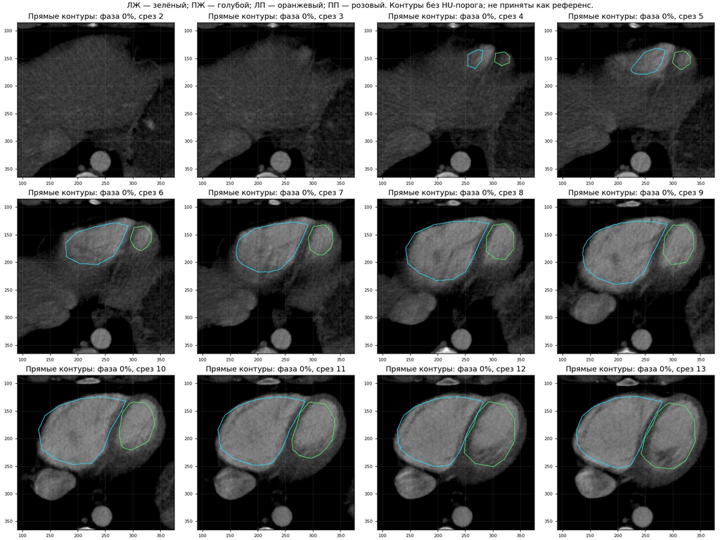

Рисунок 12. Исправленные кандидатные контуры, фаза 0%, срезы 2–13. Разметка выполнена с доступом к автоматическим контурам; анатомическая точность не подтверждена независимым разметчиком.

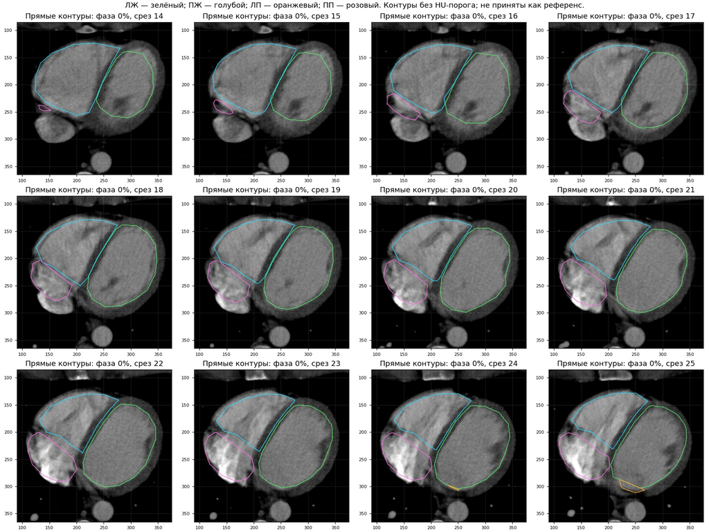

Рисунок 13. Исправленные кандидатные контуры, фаза 0%, срезы 14–25. Разметка выполнена с доступом к автоматическим контурам; анатомическая точность не подтверждена независимым разметчиком.

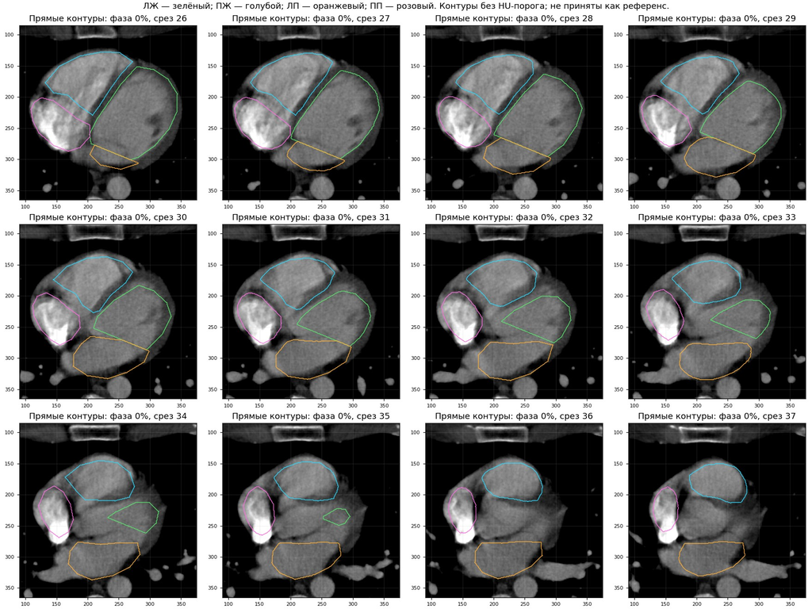

Рисунок 14. Исправленные кандидатные контуры, фаза 0%, срезы 26–37. Разметка выполнена с доступом к автоматическим контурам; анатомическая точность не подтверждена независимым разметчиком.

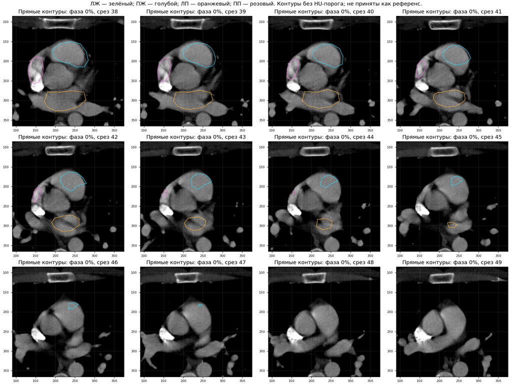

Рисунок 15. Исправленные кандидатные контуры, фаза 0%, срезы 38–49. Разметка выполнена с доступом к автоматическим контурам; анатомическая точность не подтверждена независимым разметчиком.

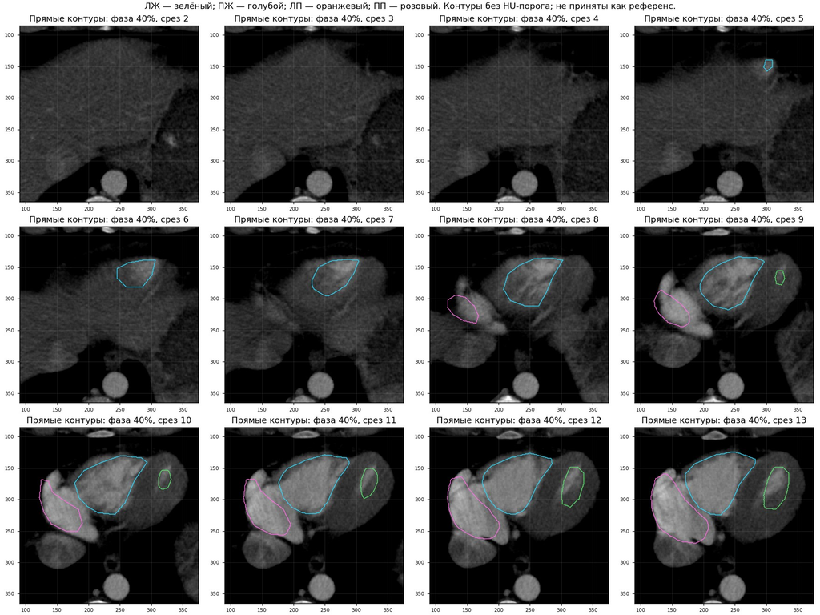

Рисунок 16. Исправленные кандидатные контуры, фаза 40%, срезы 2–13. Разметка выполнена с доступом к автоматическим контурам; анатомическая точность не подтверждена независимым разметчиком.

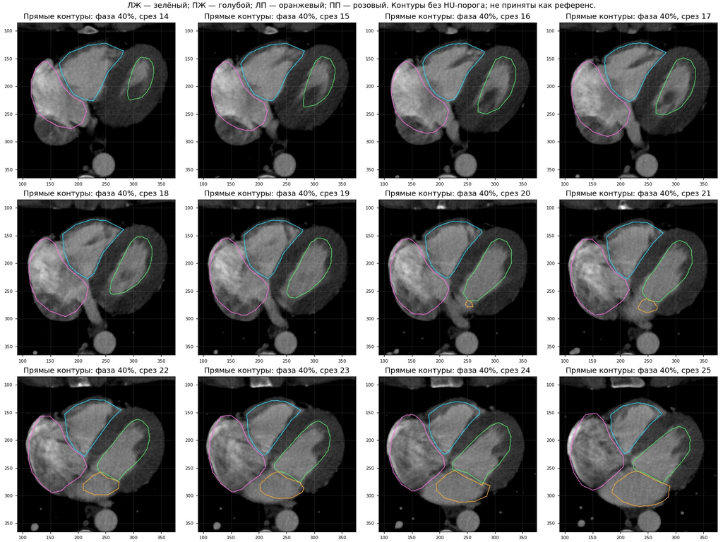

Рисунок 17. Исправленные кандидатные контуры, фаза 40%, срезы 14–25. Разметка выполнена с доступом к автоматическим контурам; анатомическая точность не подтверждена независимым разметчиком.

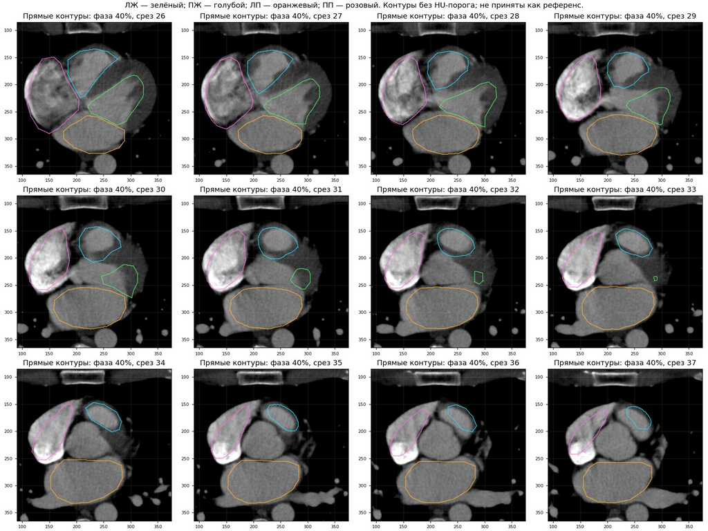

Рисунок 18. Исправленные кандидатные контуры, фаза 40%, срезы 26–37. Разметка выполнена с доступом к автоматическим контурам; анатомическая точность не подтверждена независимым разметчиком.

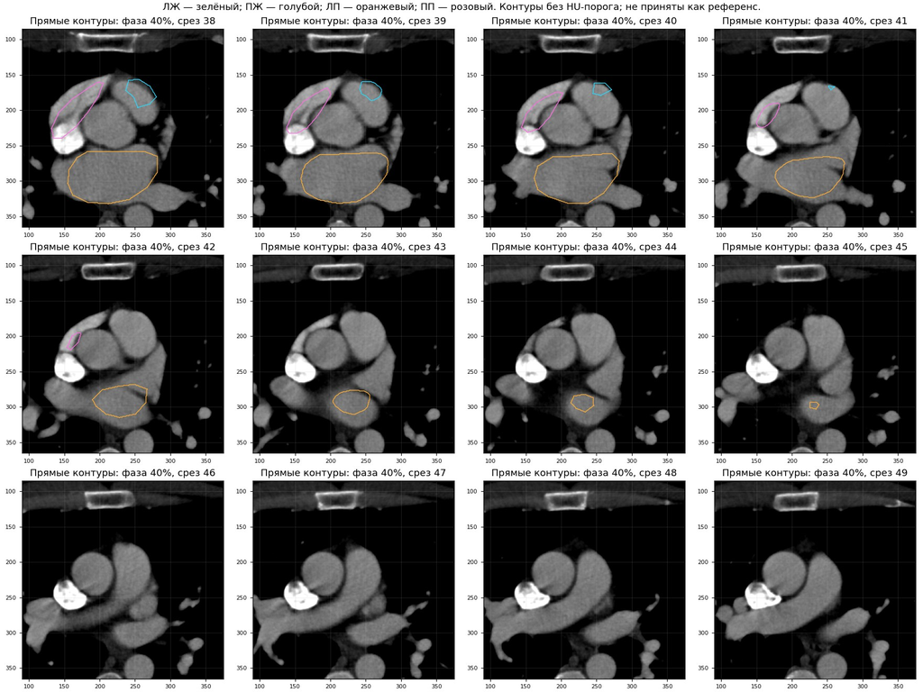

Рисунок 19. Исправленные кандидатные контуры, фаза 40%, срезы 38–49. Разметка выполнена с доступом к автоматическим контурам; анатомическая точность не подтверждена независимым разметчиком.

В средних отделах сохранено раздельное выделение желудочков и предсердий; в верхних отделах показано продолжение выходного отдела ПЖ, отсутствовавшее в прежнем кандидате. Однако по аксиальным изображениям этой толщины нельзя окончательно установить переход ПЖ в лёгочный ствол. Аналогичное ограничение относится к венозным устьям предсердий. Поэтому эти участки оставлены в перечне требующих многоплоскостной проверки, а не объявлены исправленными с известной погрешностью.

### 6.4. Миокард и наружная граница

Повторный просмотр автоматических контуров показал, что метка миокарда на выбранных срезах охватывает преимущественно стенку ЛЖ; непрерывного выделения всей свободной стенки ПЖ и стенок обоих предсердий на этих изображениях не видно. Это наблюдение по данной серии, а не утверждение о полном определении класса в обучающей разметке. Называть полученное число объёмом всей сердечной мышечной ткани пока нельзя.

В нашей разметке прежний остаток внутри наружного контура также не стал анатомическим миокардом: он содержит неопределённость полостей и основания сердца. Наружная область и миокард сохранены как отдельные черновики; их валидация не завершена. Новые прямые контуры двух фаз исправляют камеры и не подтверждают автоматически эти две дополнительные структуры.

### 6.5. Применимость опубликованных характеристик TotalSegmentator

В [описании модели камер высокого разрешения разработчиком](https://raw.githubusercontent.com/wasserth/TotalSegmentator/master/resources/heartchambers_highres_details.md) указаны 1502 обучающих и 57 валидационных изображения, рабочее разрешение приблизительно 0,73 × 0,72 × 1,0 мм и средний Dice 0,950 по классам в валидационной выборке. Эти сведения относятся к конкретной модели и её собственной выборке.

Коэффициент Dice характеризует пространственное перекрытие масок. Значение 0,950 не означает погрешность объёма 5% и не устанавливает точность межфазных разностей. Здесь исходная толщина среза 5 мм, а проверяется динамика одной исторической контрастной серии. Интерполяция к рабочей сетке модели не устраняет это различие исходных данных. Поэтому опубликованную характеристику нельзя использовать вместо локальной проверки точности объёмов.

## 7. Достоверность результатов и условия применения

Повторная проверка изменила интерпретацию исходного расчёта. Большие расхождения правых камер во многом связаны с дефектами нашей поисковой области и её переноса. Малое прежнее расхождение ЛЖ также неустойчиво: на него влияет определение измеряемого объёма. Следовательно, исходные 20-фазные кривые полезны для диагностики метода, но недостаточны для количественной валидации TotalSegmentator.

| Проверяемое свойство | Что установлено | Что ещё не установлено |
| --- | --- | --- |
| Подсчёт объёма по сохранённой маске | Совпадение КТ, физических сеток, единиц и контрольных сумм; воспроизводимые межфазные разности | Анатомическая правильность самой маски |
| Основные камеры на двух просмотренных фазах | Контуры TotalSegmentator распознают соответствующие крупные области; новая обводка устраняет грубые дефекты прежнего кандидата | Точность клапанных границ и полных поверхностей, все остальные фазы |
| Изменение объёмов | Рассчитано на 20 фазах; выявлены зависимость от определения и дефекты переноса | Погрешность относительно независимого референса |
| Миокард и наружная область | Сохранены автоматические маски и отдельные черновые области | Полнота охвата всей сердечной стенки и достоверность её объёма |
| Ударный объём и фракция выброса | В этом сравнении не рассчитывались | Независимый выбор конечных фаз и погрешность функциональных показателей |

### 7.1. Зафиксированный вывод

> На рассмотренной исторической контрастной КТ результаты TotalSegmentator прошли техническую проверку расчёта объёмов и предварительную анатомическую проверку двух фаз. Совпадение направления межфазных изменений и устранение грубых дефектов сравнительной разметки поддерживают продолжение исследовательского использования автоматических масок. Точность абсолютных объёмов, амплитуд их изменения, ударного объёма и фракции выброса настоящим исследованием не установлена.

Это положительный результат ограниченной проверки и основание для рабочего выбора метода. Такой выбор не означает принятия автоматических объёмов за истинные. В последующих расчётах маски TotalSegmentator следует обозначать как автоматические исследовательские входы с пока не установленной анатомической погрешностью. Если расчёт требует конкретной точности объёма, настоящего отчёта недостаточно для подтверждения этого требования.

**Практическое решение:** сохранить автоматические числа как исследовательские результаты с указанным происхождением, но не использовать прежнее согласие с нашим кандидатом как свидетельство их точности. Не вводить по этим расхождениям постоянные поправки к камерам и не заменять автоматические маски в основном расчёте исправленными кандидатами. Для электрического моделирования отдельно согласовать геометрическое определение крови и миокарда.

После независимой разметки можно будет оценить абсолютные расхождения, различия межфазных изменений и поверхностей, а также их воспроизводимость между разметчиками. Допустимую погрешность следует задать исходя из требуемой точности последующей оценки функции сердца или электрической модели. Сейчас такой численный допуск для этой проверки не утверждён; выбирать его после просмотра результата означало бы подгонять критерий.

## 8. Дальнейшая анатомическая проверка

1. На исходной фазе определить митральное и трёхстворчатое кольца, аортальный и лёгочный клапаны в нескольких согласованных плоскостях. Сохранить координаты, правило отсечения и неоднозначные участки. Отдельно проверить устья вен и ушки предсердий.
2. Исправить исходные границы ПЖ, предсердий и наружной области по этой анатомической разметке. Зафиксировать, что после настоящего сравнения разметчик уже видел результат TotalSegmentator; прежний вариант сохранить для истории.
3. Завершить многоплоскостную проверку фаз 0 и 40%, затем выполнить прямую проверку фаз 25, 50 и 75% и остальных фаз. Исправления выполнять по целевой КТ, а не подгонять к форме автоматической кривой.
4. Получить независимую повторную разметку хотя бы опорных фаз без показа автоматических контуров. Сопоставить различия разметчиков и их влияние на межфазные изменения объёма.
5. После принятия анатомических границ повторить сравнение по объёму и поверхности. Только при отдельно установленных конечной диастоле и конечной систоле оценивать влияние расхождений на ударный объём и фракцию выброса.

## 9. Сохранённые данные и воспроизводимость

Сохранены маски камер для трёх порогов на 20 фазах, поля деформации, исходные спецификации контуров, кандидатные маски наружной области и стенки, контрольные суммы и таблицы объёмов. Для четырёх прежних опорных фаз сохранены проекты Slicer. Отдельно подготовлены редактируемые проекты исправленных непороговых контуров фаз 0 и 40%; прежние варианты не заменены. Исходные КТ и массивы масок хранятся локально; в научный отчёт включены обезличенные иллюстрации и агрегаты.

Сравнение рассчитывает модуль `compare_authored_cardiac_volumes.py`; сборку входов и диагностических рисунков выполняет `build_old_dynamic_comparison.py`. Перенос и пороговое уточнение доступны через `transport_old_cardiac_candidates.py` и `refine_old_cardiac_candidates.py`. Результаты текущего прогона связаны с зафиксированными версиями локальных скриптов через контрольные суммы. Прямые маски строит `build_old_direct_candidates.py`, их сравнение — `build_old_anatomical_audit.py`; различие определений проверяет `audit_old_cardiac_intensity.py`. Генератор `build_old_dynamic_report.py` формирует этот ноутбук и HTML по рассчитанным данным без повторной сегментации.

Ноутбук содержит сохранённое исследовательское представление. Следующие ячейки позволяют повторить исходное и исправленное сравнения при наличии локального набора; каждая создаёт новый каталог и не заменяет исходные маски. HTML содержит только читательское представление, без исходного кода.